# Final Report

Iman Byndloss, Leah Li, and Rachel Williams

12/09/2024

# Rationale and Research Questions

The upcoming analyses seek to answer the following research questions: Does the overall activity (daily and monthly) for mammalian species differ across three Davidson County parks (Beaman, Bells Bend, and Mill Creek)? And do any park attributes (i.e., classification, size and disruptive activities) have a significant impact on the activity of the two most common species? Assuming null hypotheses, there is no significant difference between overall daily and monthly activity for mammals in the three parks, and none of the tested park attributes significantly impact animal activity.

To describe the motivation behind this research, we are interested in understanding how different factors influence mammalian species activity in urban parks. Parks like Beaman, Bells Bend, and Mill Creek not only provide essential green spaces for humans but also serve as critical habitats for wildlife. Our curiosity lies in exploring how park attributes, such as size and unique features, shape species behavior over time. By understanding these dynamics, we hope to foster greater appreciation for biodiversity in urban environments and support park management practices.

# Dataset Information

Before uploading any data sets into RStudio, the relevant csv files were examined in Excel. The two csv files used in this project are from Prof. Malu Jorge at Vanderbilt University. Prof. Malu Jorge identifies 06/28/2021 to 05/19/22 as one of the longest time periods of consistent data collection by her lab. Although nine parks are listed within “cluster.name” of “Wildlife Insights (2021-2022).csv”, only three parks cover the majority of the aforementioned time period based on the earliest “start_date” and latest “end_date” for each park in “All Deployments (2019-2022).csv”. Those parks include Beaman (06/29/2021-12/31/2022), Bells Bend (06/28/2021-05/19/2022), and Mills Creek(07/20/2021-04/23/2022). To establish a consistent study period for this project in accordance with these three parks, the following time period will be used: 07/20/2021-4/23/2022 (278 days). During this study period, GardePro A3, Browning Strike Force HD ProX, and HAPIMP PH770-8D trail cameras were used; these models have motion detectors and were programmed to have a delay between consecutive triggers. Lab members placed camera traps at various sites (one camera per site) within the forested areas of these parks.

In RStudio, the data wrangling process involved six main sections: 1) Wildlife IDs from Prof. Malu Jorge’s Lab at Vanderbilt University, 2) Camera Counts Per Day (i.e., sampling effort), 3) Species Data (filtered, adjusted, and totals), 4) Spatial Data, 5) Merging Data Frames (species and spatial data), and 6) Save Processed Data.

In the first section (which involves “Wildlife Insights (2021-2022).csv”), we added columns for date and time based on a pre-existing combined date-time column and independently isolated camera trap data for the parks of interest.

In the second section (which involves “All Deployments (2019-2022).csv”), we independently isolated deployment data for the parks of interest before counting the cameras deployed at each park for every day during the study period.

The third section includes 1) filtering by hour, 2) adjusting counts based on sampling effort, and 3) calculating monthly and full period totals in wildlife IDs. To explain, first, the daily wildlife IDs for each species must be filtered by hour at every camera trap separately to remove repeated counts of the same individual(s). Second, to account for sampling effort, the daily wildlife IDs for each species need to be divided by the number of cameras out each day to standardize the data. Third, monthly and full time period totals are calculated to compare data between parks; in this case, totals can be used rather than averages or rolling averages since sampling effort is already accounted for, a consistent time period is already established across parks, and counts are not guaranteed each day.

The fourth section includes spatial data on parks in Nashville, TN (retrieved from Nashville Open Data at the following link: https://datanashvillegov-nashville.hub.arcgis.com/datasets/13c1aa2bafdd43f4b3cd132e7256a172_0/explore?location=36.167341%2C-86.763938%2C9.17). The csv version of this shapefile was examined in Excel prior to uploading to RStudio. From that initial examination, it became clear that numerous similarities exist between these three parks (e.g., being open daily, not allowing horseback riding, and not having any sports fields or courts available). Still, there are certain attributes that make each of these three parks unique from one another. To briefly explain, Beaman (a regional park established in 1996) is the largest of the three parks at 2170.89186 acres, open dawn to 11pm, and more restrictive with no walking or jogging on certain trails. Bells Bend (a regional park established in 2007) is an intermediate size at 809.59 acres, has a more restrictive schedule being open dawn to dusk, and allows more activities, including mountain biking, camping, and fishing. Lastly, Mill Creek (a community park established in 2013) is the smallest of the three parks at 85.62 acres, open dawn to 11pm, and has no hiking trails.

The fifth section merges the daily and monthly species data frames with the park attributes data frame. These merges are completed in preparation for a series of two-sample t-tests. By selecting three unique park characteristics (i.e., park classification, size, and disruptive activities), each park gets the opportunity to be compared against the other two parks. Notably, although there are other characteristics that distinguish these parks from one another (as mentioned in the previous section), we expect the three chosen characteristics to have the largest influences on species activity. It is also important to mention that while park classification takes into account the size of the park, it also relates to other factors, like who the park serves.

The sixth and final section simply saves the final processed data frames into the “Processed” folder, which is within the “Data” folder of this project. There are six data frames within that folder, which we loaded into this report during set up. Below is more information on those data frames.

```r
# For the data sets developed during the first through third sections...
# Retrieve the names of the columns and generate a summary of the data frames
names(Daily_Species_Counts)
```

```
## [1] "Date"          "CountRaw"      "CountAdjusted" "Species"
## [5] "ParkName"
```

```r
summary(Daily_Species_Counts)
```

```
##          Date          CountRaw       CountAdjusted
##  2021-07-20:   37   Min.   : 0.0000   Min.   : 0.0000
##  2021-07-21:   37   1st Qu.: 0.0000   1st Qu.: 0.0000
##  2021-07-22:   37   Median : 0.0000   Median : 0.0000
##  2021-07-23:   37   Mean   : 0.4754   Mean   : 0.1611
##  2021-07-24:   37   3rd Qu.: 0.0000   3rd Qu.: 0.0000
##  2021-07-25:   37   Max.   :43.0000   Max.   :21.5000
##  (Other)   :10064
##                        Species                     ParkName
##  Coyote                    : 834   Alvin G. Beaman Park:3892
##  Eastern Chipmunk          : 834   Bells Bend Park     :3336
##  Eastern Cottontail        : 834   Mill Creek Park     :3058
##  Eastern Gray Squirrel     : 834
##  North American River Otter: 834
##  Northern Raccoon          : 834
##  (Other)                   :5282
```

```r
names(Monthly_Species_Counts)
```

```
## [1] "Month"         "Species"       "CountAdjusted" "ParkName"
```

```r
summary(Monthly_Species_Counts)
```

```
##      Month                           Species    CountAdjusted
##  2021-07: 37   Coyote                    : 30   Min.   :  0.0000
##  2021-08: 37   Eastern Chipmunk          : 30   1st Qu.:  0.0000
##  2021-09: 37   Eastern Cottontail        : 30   Median :  0.3667
##  2021-10: 37   Eastern Gray Squirrel     : 30   Mean   :  4.4794
##  2021-11: 37   North American River Otter: 30   3rd Qu.:  2.5625
##  2021-12: 37   Northern Raccoon          : 30   Max.   :107.0000
##  (Other):148   (Other)                   :190
##                  ParkName
##  Alvin G. Beaman Park:140
##  Bells Bend Park     :120
##  Mill Creek Park     :110
##
##
##
##
```

```r
names(Full_Period_Species_Counts)
```

```
## [1] "Species"       "CountAdjusted" "ParkName"
```

```r
summary(Full_Period_Species_Counts)
```

```
##                        Species   CountAdjusted                     ParkName
##  Coyote                    : 3   Min.   :  0.000   Alvin G. Beaman Park:14
##  Eastern Chipmunk          : 3   1st Qu.:  1.700   Bells Bend Park     :12
##  Eastern Cottontail        : 3   Median :  5.917   Mill Creek Park     :11
##  Eastern Gray Squirrel     : 3   Mean   : 44.794
##  North American River Otter: 3   3rd Qu.: 45.000
##  Northern Raccoon          : 3   Max.   :506.833
##  (Other)                   :19
```

```r
# For the data set developed during the fourth section...
# Retrieve the names of the columns and generate a summary of the data frames
names(Park_Attributes)
```

```
##  [1] "Name"       "PARK_ID"    "Latitude"   "Longitude"  "YearEstabl"
##  [6] "Acres"      "DaysOpen"   "Hours"      "Phone"      "Webstie"
## [11] "Address"    "Restroom"   "CommunityC" "NatureCent" "ADA"
## [16] "Concession" "DogPark"    "Baseball"   "BasketBall" "MountainBi"
## [21] "Boating"    "Camping"    "DiscGolf"   "Fishing"    "GolfCourse"
## [26] "Hiking"     "HistoricSi" "HorsebackR" "Lake"       "Picnic"
## [31] "PicnicShel" "Playground" "SchoolSite" "Soccer"     "SprayPark"
## [36] "SkatePark"  "Swimming"   "Tennis2"    "WalkJog"    "Email"
## [41] "Descriptio" "Status"     "Volleyball" "FootballMu" "CanoeLaunc"
## [46] "CommunityG" "CommonName" "Classifica" "City"       "State"
## [51] "ZipCode"    "GlobalID"   "geometry"
```

```r
summary(Park_Attributes)
```

```
##      Name             PARK_ID             Latitude       Longitude
##  Length:3           Length:3           Min.   :36.01   Min.   :-86.93
##  Class :character   Class :character   1st Qu.:36.08   1st Qu.:-86.92
##  Mode  :character   Mode  :character   Median :36.15   Median :-86.92
##                                        Mean   :36.14   Mean   :-86.85
##                                        3rd Qu.:36.21   3rd Qu.:-86.81
##                                        Max.   :36.26   Max.   :-86.69
##    YearEstabl       Acres           DaysOpen            Hours
##  Min.   :1996   Min.   :  85.62   Length:3           Length:3
##  1st Qu.:2002   1st Qu.: 447.61   Class :character   Class :character
##  Median :2007   Median : 809.59   Mode  :character   Mode  :character
##  Mean   :2005   Mean   :1022.03
##  3rd Qu.:2010   3rd Qu.:1490.24
##  Max.   :2013   Max.   :2170.89
##     Phone             Webstie            Address            Restroom
##  Length:3           Length:3           Length:3           Length:3
##  Class :character   Class :character   Class :character   Class :character
##  Mode  :character   Mode  :character   Mode  :character   Mode  :character
##
##
##
##   CommunityC         NatureCent            ADA             Concession
##  Length:3           Length:3           Length:3           Length:3
##  Class :character   Class :character   Class :character   Class :character
##  Mode  :character   Mode  :character   Mode  :character   Mode  :character
##
##
##
##    DogPark            Baseball          BasketBall         MountainBi
##  Length:3           Length:3           Length:3           Length:3
##  Class :character   Class :character   Class :character   Class :character
##  Mode  :character   Mode  :character   Mode  :character   Mode  :character
##
##
##
##    Boating            Camping            DiscGolf           Fishing
##  Length:3           Length:3           Length:3           Length:3
##  Class :character   Class :character   Class :character   Class :character
##  Mode  :character   Mode  :character   Mode  :character   Mode  :character
##
```

[output cut: 43 more lines]

```
##
##      City              State             ZipCode            GlobalID
##  Length:3           Length:3           Length:3           Length:3
##  Class :character   Class :character   Class :character   Class :character
##  Mode  :character   Mode  :character   Mode  :character   Mode  :character
##
##
##
##           geometry
##  MULTIPOLYGON :3
##  epsg:2274    :0
##  +proj=lcc ...:0
##
##
##
```

```r
# For the data sets developed during the fifth section...
# Retrieve the names of the columns and generate a summary of the data frames
names(Daily_Merge)
```

```
## [1] "ParkName"             "Date"                 "CountRaw"
## [4] "CountAdjusted"        "Species"              "Classification"
## [7] "Size"                 "DisruptiveActivities"
```

```r
summary(Daily_Merge)
```

```
##                  ParkName            Date          CountRaw
##  Alvin G. Beaman Park:3892   2021-07-20:   37   Min.   : 0.0000
##  Bells Bend Park     :3336   2021-07-21:   37   1st Qu.: 0.0000
##  Mill Creek Park     :3058   2021-07-22:   37   Median : 0.0000
##                              2021-07-23:   37   Mean   : 0.4754
##                              2021-07-24:   37   3rd Qu.: 0.0000
##                              2021-07-25:   37   Max.   :43.0000
##                              (Other)   :10064
##  CountAdjusted                           Species       Classification
##  Min.   : 0.0000   Coyote                    : 834   Community:3058
##  1st Qu.: 0.0000   Eastern Chipmunk          : 834   Regional :7228
##  Median : 0.0000   Eastern Cottontail        : 834
##  Mean   : 0.1611   Eastern Gray Squirrel     : 834
##  3rd Qu.: 0.0000   North American River Otter: 834
##  Max.   :21.5000   Northern Raccoon          : 834
##                    (Other)                   :5282
##       Size      DisruptiveActivities
##  <1000ac:6394   No :6950
##  >1000ac:3892   Yes:3336
##
##
##
##
##
```

```r
names(Monthly_Merge)
```

```
## [1] "ParkName"             "Month"                "Species"
## [4] "CountAdjusted"        "Classification"       "Size"
## [7] "DisruptiveActivities"
```

```r
summary(Monthly_Merge)
```

```
##                  ParkName       Month                           Species
##  Alvin G. Beaman Park:140   2021-07: 37   Coyote                    : 30
##  Bells Bend Park     :120   2021-08: 37   Eastern Chipmunk          : 30
##  Mill Creek Park     :110   2021-09: 37   Eastern Cottontail        : 30
##                             2021-10: 37   Eastern Gray Squirrel     : 30
##                             2021-11: 37   North American River Otter: 30
##                             2021-12: 37   Northern Raccoon          : 30
##                             (Other):148   (Other)                   :190
##  CountAdjusted        Classification      Size     DisruptiveActivities
##  Min.   :  0.0000   Community:110    <1000ac:230   No :250
##  1st Qu.:  0.0000   Regional :260    >1000ac:140   Yes:120
##  Median :  0.3667
##  Mean   :  4.4794
##  3rd Qu.:  2.5625
##  Max.   :107.0000
##
```

# Exploratory Analysis

## Map of park boundaries

To visually represent these three parks spatially, we created an interactive map of each park’s boundary with information on its attributes stored in the associated popup.

```r
# Map parks with attributes with color code based on park name
mapView(Park_Attributes, zcol = "Name", legend.title = "Park Name")
```

[interactive chart not shown]

## Total adjusted counts

To consider how the total counts for each species compared across parks, we created a bar graph.

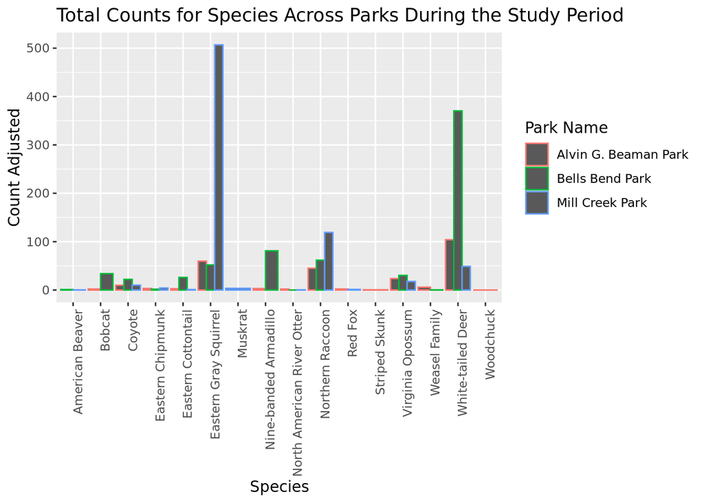

```r
# Graph full period data
FP.plot <- ggplot(Full_Period_Species_Counts, aes(x = Species,
                                                  y = CountAdjusted,
                                                  color = ParkName)) +
  geom_col(position = "dodge") + #ensures bars do not overlap
  labs(title = "Total Counts for Species Across Parks During the Study Period",
       x = "Species",
       y = "Count Adjusted",
       color = "Park Name") +
  theme(axis.text.x = element_text(angle = 90, hjust = 1)) #tilts species names
FP.plot
```

```r
ggsave(filename="Output/FP.plot_data.pdf", plot= FP.plot)
```

Given that the total counts of species is particularly relevant to answer our second question, in which we need to know the two most common species. To address this topic, we aggregated the data to add up the adjusted counts for each species to confirm which species are have the highest adjusted counts regardless of park. Once we did this, we sorted it in descending order and looked at which species were the two most abundant.

```r
aggregated_data <- Daily_Species_Counts %>%
  group_by(Species) %>%
  summarise(total_count = sum(CountAdjusted, na.rm = TRUE))

sorted_data <- aggregated_data %>%
  arrange(desc(total_count))

most_abundant_species <- head(sorted_data, 5)

kable(most_abundant_species, caption = "Most Abundant Species")
```

Most Abundant Species

| Species | total_count |
| --- | --- |
| Eastern Gray Squirrel | 618.43333 |
| White-tailed Deer | 523.21667 |
| Northern Raccoon | 225.73333 |
| Nine-banded Armadillo | 84.06667 |
| Virginia Opossum | 71.66667 |

> According to these results, eastern gray squirrel and white-tailed deer are the top two most abundant species, with around 618.43 and 523.21 adjusted counts respectively. These species are followed by northern raccoon (225.73), nine-banded armadillo (84.07), and virginia opposum (71.67).

## Adjusted counts over time

To graph adjusted counts over time for all species in each park, we created line graphs from daily and monthly data.

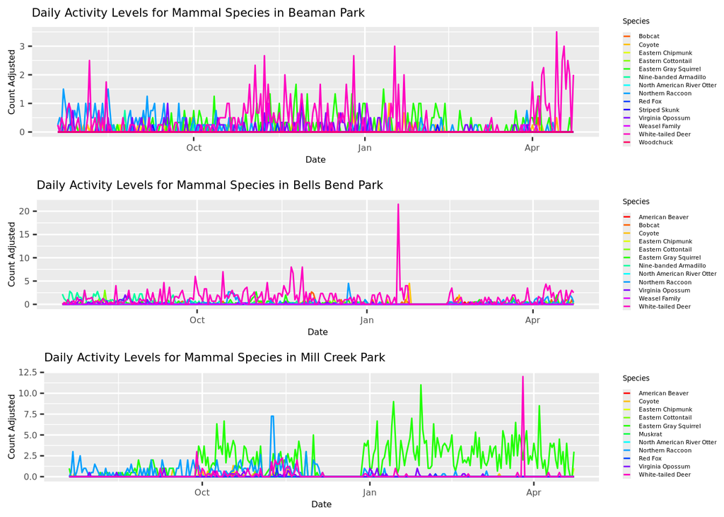

```r
# Ensure the Date and Month columns are classed correctly
Daily_Species_Counts$Date <- as.Date(Daily_Species_Counts$Date)
Monthly_Species_Counts$Month <- as.Date(paste0(Monthly_Species_Counts$Month,
                                               "-01"))

# Ensure species in alphabetical order
# Generate and assign rainbow colors
# Apply sorted species factor to data sets
all_species <- sort(unique(Daily_Species_Counts$Species))
species_colors_rainbow <- rainbow(length(all_species))
species_colors <- setNames(species_colors_rainbow, all_species)
Daily_Species_Counts$Species <- factor(Daily_Species_Counts$Species,
                                       levels = all_species)
Monthly_Species_Counts$Species <- factor(Monthly_Species_Counts$Species,
                                         levels = all_species)

# Filter daily and monthly data for each park
Beaman_Daily <- Daily_Species_Counts %>% filter(
  ParkName == "Alvin G. Beaman Park")
Beaman_Monthly <- Monthly_Species_Counts %>% filter(
  ParkName == "Alvin G. Beaman Park")

BellsBend_Daily <- Daily_Species_Counts %>% filter(
  ParkName == "Bells Bend Park")
BellsBend_Monthly <- Monthly_Species_Counts %>% filter(
  ParkName == "Bells Bend Park")

MillCreek_Daily <- Daily_Species_Counts %>% filter(
  ParkName == "Mill Creek Park")
MillCreek_Monthly <- Monthly_Species_Counts %>% filter(
  ParkName == "Mill Creek Park")

# Graph daily and monthly data for each park
BD.plot <- ggplot(Beaman_Daily, aes(x = Date,
                                    y = CountAdjusted,
                                    color = Species)) +
  geom_line() +
  scale_color_manual(values = species_colors) +
  labs(title = "Daily Activity Levels for Mammal Species in Beaman Park",
       x = "Date",
       y = "Count Adjusted",
       color = "Species")

BM.plot <- ggplot(Beaman_Monthly, aes(x = Month,
                                      y = CountAdjusted,
                                      color = Species)) +
  geom_line() +
  scale_color_manual(values = species_colors) +
  labs(title = "Monthly Activity Levels for Mammal Species in Beaman Park",
       x = "Date",
       y = "Count Adjusted",
       color = "Species")

BBD.plot <- ggplot(BellsBend_Daily, aes(x = Date,
                                        y = CountAdjusted,
                                        color = Species)) +
  geom_line() +
  scale_color_manual(values = species_colors) +
  labs(title = "Daily Activity Levels for Mammal Species in Bells Bend Park",
       x = "Date",
       y = "Count Adjusted",
       color = "Species")

BBM.plot <- ggplot(BellsBend_Monthly, aes(x = Month,
                                          y = CountAdjusted,
                                          color = Species)) +
  geom_line() +
  scale_color_manual(values = species_colors) +
  labs(title = "Monthly Activity Levels for Mammal Species in Bells Bend Park",
       x = "Date",
       y = "Count Adjusted",
       color = "Species")

MCD.plot <- ggplot(MillCreek_Daily, aes(x = Date,
                                        y = CountAdjusted,
                                        color = Species)) +
  geom_line() +
  scale_color_manual(values = species_colors) +
  labs(title = "Daily Activity Levels for Mammal Species in Mill Creek Park",
       x = "Date",
       y = "Count Adjusted",
       color = "Species")

MCM.plot <- ggplot(MillCreek_Monthly, aes(x = Month,
                                          y = CountAdjusted,
                                          color = Species)) +
  geom_line() +
  scale_color_manual(values = species_colors) +
  labs(title = "Monthly Activity Levels for Mammal Species in Mill Creek Park",
       x = "Date",
       y = "Count Adjusted",
       color = "Species")

# Create a function to reduce label sizes
adjust_labels <- function(plot) {
  plot +
    theme(plot.title = element_text(size = 8),
          axis.title.x = element_text(size = 6),
          axis.title.y = element_text(size = 6),
          axis.text.x = element_text(size = 6),
          axis.text.y = element_text(size = 6))
}

# Apply label adjustments to all plots
BD.plot <- adjust_labels(BD.plot)
BM.plot <- adjust_labels(BM.plot)
BBD.plot <- adjust_labels(BBD.plot)
BBM.plot <- adjust_labels(BBM.plot)
MCD.plot <- adjust_labels(MCD.plot)
MCM.plot <- adjust_labels(MCM.plot)

# Create a function to reduce legend size
adjust_legend <- function(plot) {
  plot +
    theme(legend.key.size = unit(0.2, "cm"),
          legend.text = element_text(size = 4),
          legend.title = element_text(size = 5))
}

# Apply legend adjustments to all plots
BD.plot <- adjust_legend(BD.plot)
BM.plot <- adjust_legend(BM.plot)
BBD.plot <- adjust_legend(BBD.plot)
BBM.plot <- adjust_legend(BBM.plot)
MCD.plot <- adjust_legend(MCD.plot)
MCM.plot <- adjust_legend(MCM.plot)

# Display daily and monthly plots together
plot_grid(BD.plot, BBD.plot, MCD.plot,
          ncol = 1) #vertical alignment of plots
```

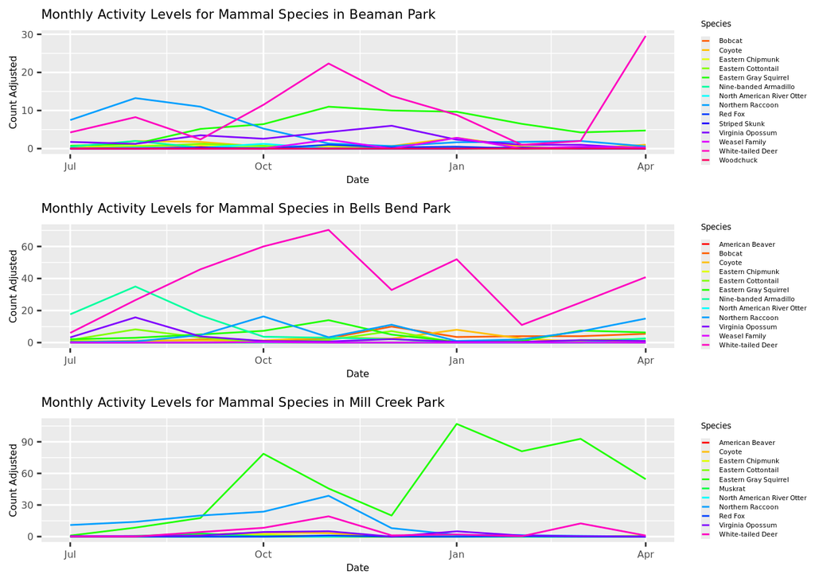

```r
plot_grid(BM.plot, BBM.plot, MCM.plot,
          ncol = 1) #vertical alignment of plots
```

> Once again, the distinct of species activities across the three parks are emphasized in this graph. Looking at the scale of the y-axes within the daily graphs, Beaman has the smallest range of values, reaching not much more than 3 counts adjusted, and Bells Bend has the largest range of values, reaching more than 20 counts adjusted. Similarly, looking at the scale of the y-axes within the monthly graphs, Beaman still has the smallest range of values, reaching around 30 counts adjusted, but in this case, Mill Creek has the largest range of values, reaching more than 90 counts adjusted. It is important to mention that daily activity fluctuates more than monthly activity, an expected reality that tends to occur as a result of the variability of short-term factors, like weather, human activity, and animal behaviors.

To highlight the species of interest regarding the second research question, we graphed the daily and monthly adjusted counts for white-tailed deer and eastern gray squirrel in each park over time.

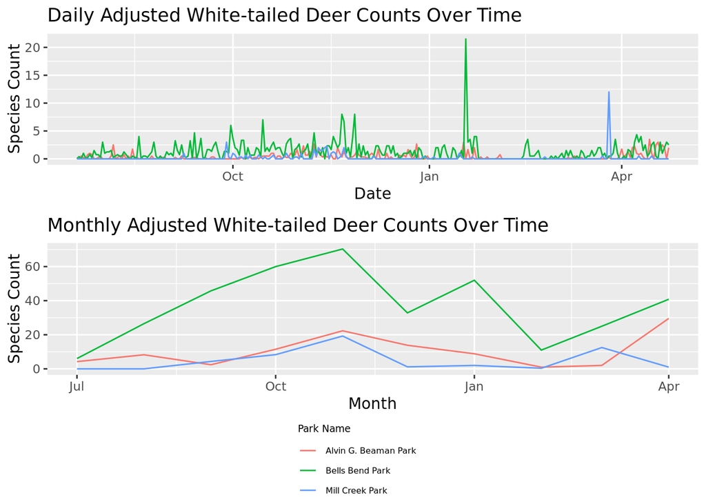

```r
# Filter data for species
Daily_Deer_Counts <- Daily_Species_Counts %>%
  filter(Species == "White-tailed Deer") %>%
   mutate(Date = as.Date(Date))

Monthly_Deer_Counts <- Monthly_Species_Counts %>%
  filter(Species == "White-tailed Deer") %>%
   mutate(Month = as.Date(Month))

Daily_Squirrel_Counts <- Daily_Species_Counts %>%
  filter(Species == "Eastern Gray Squirrel") %>%
   mutate(Date = as.Date(Date))

Monthly_Squirrel_Counts <- Monthly_Species_Counts %>%
  filter(Species == "Eastern Gray Squirrel") %>%
   mutate(Month = as.Date(Month))

# Graphs for each species counts over time in which coloring is based on park
DailyDeer.plot <- ggplot(Daily_Deer_Counts, aes(x= Date, y= CountAdjusted,
                                  color = ParkName)) +
  geom_line() +
  theme(legend.position = "none") +
  labs(title = "Daily Adjusted White-tailed Deer Counts Over Time",
       y = "Species Count",
       color = "Park Name")

MonthlyDeer.plot <- ggplot(Monthly_Deer_Counts, aes(x= Month, y= CountAdjusted,
                                    color = ParkName)) +
  geom_line() +
  theme(legend.position = "none") +
  labs(title = "Monthly Adjusted White-tailed Deer Counts Over Time",
       y = "Species Count",
       color = "Park Name")

DailySquirrel.plot <- ggplot(Daily_Squirrel_Counts, aes(x= Date,
                                                        y= CountAdjusted,
                                                        color = ParkName)) +
  geom_line() +
  theme(legend.position = "none") +
  labs(title = "Daily Adjusted Eastern Gray Squirrel Counts Over Time",
       y = "Species Count",
       color = "Park Name")

MonthlySquirrel.plot <- ggplot(Monthly_Squirrel_Counts, aes(x= Month,
                                                            y= CountAdjusted,
                                                            color = ParkName)) +
  geom_line() +
  theme(legend.position = "none") +
  labs(title = "Monthly Adjusted Eastern Gray Squirrel Counts Over Time",
       y = "Species Count",
       color = "Park Name")

# Extract the legend
legend <- cowplot::get_legend(
  ggplot(Monthly_Deer_Counts, aes(x = Month, y = CountAdjusted,
                                  color = ParkName)) +
    geom_line() +
    theme_minimal() +
    theme(
      legend.key.size = unit(0.5, "cm"),
      legend.text = element_text(size = 6),
      legend.title = element_text(size = 7)
    ) +
    labs(color = "Park Name"))
# Display daily and monthly plots together
plot_grid(DailyDeer.plot, MonthlyDeer.plot, legend,
          ncol = 1, #vertical alignment of plots
          rel_heights = c(1, 1, 0.4))
```

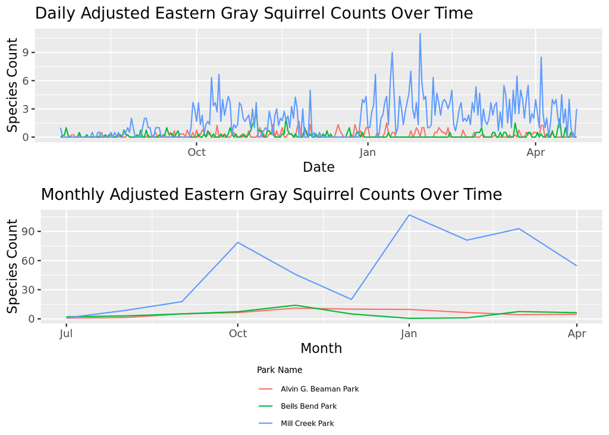

```r
plot_grid(DailySquirrel.plot, MonthlySquirrel.plot, legend,
          ncol = 1, #vertical alignment of plots
          rel_heights = c(1, 1, 0.4))
```

> With a visual representation of eastern gray squirrel and white-tailed deer activity across the three parks, it is clear Mill Creek has considerably more eastern gray squirrel activity than the other parks and Bells Bend has considerably more white-tailed deer activity than the other parks. Notably, looking at the scales of the y-axes, while the highest record of daily activity for white-tailed deer is more than eastern gray squirrel, reaching more than 20 counts adjusted compared to not much more than 11 counts adjusted. Contrastingly, the highest record of monthly activity for eastern gray squirrel is more than white-tailed deer, reaching more than 90 counts adjusted compared to around 70 counts adjusted.

# Analysis

The upcoming analyses seek to answer the following research questions: Does the overall activity (daily and monthly) for mammalian species differ across three Davidson County parks (Beaman, Bells Bend, and Mill Creek)? And do any park attributes (i.e., classification, size and disruptive activities) have a significant impact on the activity of the two most common species? Assuming null hypotheses, there is no significant difference between overall daily and monthly activity for mammals in the three parks, and none of the tested park attributes significantly impact the activity of eastern gray squirrels and white-tailed deer.

## Two-way ANOVA Test

Question 1: Does the overall activity (daily and monthly) for mammalian species differ across three Davidson County parks (Beaman, Bells Bend, and Mill Creek)?

These two-way anova seek to determine if the overall activity (daily and monthly) for mammalian species significantly differ between Beaman Park, Bells Bend Park, and Mill Creek Park.

### Daily Species Activity (Park and Species)

```r
# Perform the two-way ANOVA with interaction
daily_anova_result <- aov(CountAdjusted ~ ParkName * Species, data = Daily_Species_Counts)

# View the ANOVA summary
summary(daily_anova_result)
```

```
##                     Df Sum Sq Mean Sq F value Pr(>F)
## ParkName             2   55.9   27.96   99.91 <2e-16 ***
## Species             15  599.6   39.97  142.86 <2e-16 ***
## ParkName:Species    19  676.2   35.59  127.19 <2e-16 ***
## Residuals        10249 2867.8    0.28
## ---
## Signif. codes:  0 '***' 0.001 '**' 0.01 '*' 0.05 '.' 0.1 ' ' 1
```

> ANOVA Result Interpretation:

> The two-way ANOVA analysis here evaluated the effects of park and species, as well as their interaction, on daily activity levels (measured as adjusted counts). In terms of the main effects, the results revealed daily activity levels differ significantly across parks (Df = 2, F-value = 99.91, p-value = <2e-16) and species (Df = 15, F-value = 142.86, p-value = <2e-16). In terms of the interaction effect, the interaction between park and species was also significant (Df = 19, F-value = 127.19, p-value = <2e-16). This finding highlights that the effect of park on daily activity is not consistent across all species and the effect of species on daily activity is not consistent across all parks.

> These results suggest that both park-specific factors (e.g., habitat type, management practices) and species-specific traits (e.g., behavior, ecological preferences) play critical roles in determining daily activity levels. Moreover, the significant interaction effect emphasizes the importance of considering the combined influence of these two factors when analyzing daily activity.

#### Post-Hoc Test

```r
# If the interaction term is significant, perform a post-hoc test
Daily_Species_Counts$ParkName <- as.factor(Daily_Species_Counts$ParkName)
Daily_Species_Counts$Species <- as.factor(Daily_Species_Counts$Species)

# Tukey's HSD test for the interaction term (ParkName * Species)
library(agricolae)
daily_tukey_result <- TukeyHSD(daily_anova_result, "ParkName:Species")

# Extract significant results
daily_tukey_df <- as.data.frame(daily_tukey_result$`ParkName:Species`)
daily_tukey_df$Comparison <- rownames(daily_tukey_result$`ParkName:Species`)
rownames(daily_tukey_df) <- NULL

# Filter significant comparisons
daily_significant_tukey <- subset(daily_tukey_df, `p adj` < 0.05)

# Print the top 10 significant results
head(daily_significant_tukey, 10)
```

|  | diff | lwr | upr | p adj | Comparison |
| --- | --- | --- | --- | --- | --- |
| 61 | 0.2113309 | 0.033001641 | 0.3896602 | 2.405810e-03 | Alvin G. Beaman Park:Eastern Gray Squirrel-Bells Bend Park:American Beaver |
| 62 | 0.1829137 | 0.004584374 | 0.3612430 | 3.447013e-02 | Bells Bend Park:Eastern Gray Squirrel-Bells Bend Park:American Beaver |
| 63 | 1.8195444 | 1.641215070 | 1.9978737 | 0.000000e+00 | Mill Creek Park:Eastern Gray Squirrel-Bells Bend Park:American Beaver |
| 68 | 0.2880096 | 0.109680298 | 0.4663389 | 1.598396e-07 | Bells Bend Park:Nine-banded Armadillo-Bells Bend Park:American Beaver |
| 74 | 0.2181655 | 0.039836173 | 0.3964948 | 1.168225e-03 | Bells Bend Park:Northern Raccoon-Bells Bend Park:American Beaver |
| 75 | 0.4247602 | 0.246430897 | 0.6030895 | 0.000000e+00 | Mill Creek Park:Northern Raccoon-Bells Bend Park:American Beaver |
| 88 | 0.3705036 | 0.192174303 | 0.5488329 | 0.000000e+00 | Alvin G. Beaman Park:White-tailed Deer-Bells Bend Park:American Beaver |
| 89 | 1.3284173 | 1.150087972 | 1.5067466 | 0.000000e+00 | Bells Bend Park:White-tailed Deer-Bells Bend Park:American Beaver |
| 106 | 0.2137290 | 0.035399722 | 0.3920583 | 1.873439e-03 | Alvin G. Beaman Park:Eastern Gray Squirrel-Mill Creek Park:American Beaver |
| 107 | 0.1853118 | 0.006982456 | 0.3636410 | 2.818104e-02 | Bells Bend Park:Eastern Gray Squirrel-Mill Creek Park:American Beaver |

> Post-Hoc Result Interpretation:

> In total, the post-hoc test for daily activity levels revealed 214 significant comparisons.

### Monthly Species Activity (Park and Species)

```r
# Perform the two-way ANOVA with interaction
monthly_anova_result <- aov(CountAdjusted ~ ParkName * Species, data = Monthly_Species_Counts)

# View the ANOVA summary
summary(monthly_anova_result)
```

```
##                   Df Sum Sq Mean Sq F value   Pr(>F)
## ParkName           2   1554   777.2   11.81 1.11e-05 ***
## Species           15  16669  1111.3   16.88  < 2e-16 ***
## ParkName:Species  19  18798   989.4   15.03  < 2e-16 ***
## Residuals        333  21922    65.8
## ---
## Signif. codes:  0 '***' 0.001 '**' 0.01 '*' 0.05 '.' 0.1 ' ' 1
```

> ANOVA Result Interpretation:

> The two-way ANOVA analysis here evaluated the effects of park and species, as well as their interaction, on monthly activity levels (measured as adjusted counts). In terms of the main effects, the results revealed daily activity levels differ significantly across parks (Df = 2, F-value = 11.81, p-value = 1.11e-05) and species (Df = 15, F-value = 16.88, p-value = <2e-16). In terms of the interaction effect, the interaction between park and species was also significant (Df = 19, F-value = 15.03, p-value = <2e-16).

> With these results being similar to the results for daily activity, it can be understood that the effects of park-specific, species-specific, and interactive factors are consistent over longer time scales.

#### Post-Hoc Test

```r
# If the interaction term is significant, perform a post-hoc test
Monthly_Species_Counts$ParkName <- as.factor(Monthly_Species_Counts$ParkName)
Monthly_Species_Counts$Species <- as.factor(Monthly_Species_Counts$Species)

# Tukey's HSD test for the interaction term (ParkName * Species)
library(agricolae)
monthly_tukey_result <- TukeyHSD(monthly_anova_result, "ParkName:Species")

# Extract significant results
monthly_tukey_df <- as.data.frame(monthly_tukey_result$`ParkName:Species`)
monthly_tukey_df$Comparison <- rownames(monthly_tukey_result$`ParkName:Species`)
rownames(monthly_tukey_df) <- NULL

# Filter significant comparisons
monthly_significant_tukey <- subset(monthly_tukey_df, `p adj` < 0.05)

# Print the top 10 significant results
head(monthly_significant_tukey, 10)
```

|  | diff | lwr | upr | p adj | Comparison |
| --- | --- | --- | --- | --- | --- |
| 63 | 50.58333 | 36.02293 | 65.14373 | 3.911316e-13 | Mill Creek Park:Eastern Gray Squirrel-Bells Bend Park:American Beaver |
| 89 | 36.93000 | 22.36960 | 51.49040 | 8.375522e-13 | Bells Bend Park:White-tailed Deer-Bells Bend Park:American Beaver |
| 108 | 50.65000 | 36.08960 | 65.21040 | 3.911316e-13 | Mill Creek Park:Eastern Gray Squirrel-Mill Creek Park:American Beaver |
| 134 | 36.99667 | 22.43627 | 51.55707 | 8.519851e-13 | Bells Bend Park:White-tailed Deer-Mill Creek Park:American Beaver |
| 152 | 50.47500 | 35.91460 | 65.03540 | 3.911316e-13 | Mill Creek Park:Eastern Gray Squirrel-Alvin G. Beaman Park:Bobcat |
| 178 | 36.82167 | 22.26127 | 51.38207 | 8.308909e-13 | Bells Bend Park:White-tailed Deer-Alvin G. Beaman Park:Bobcat |
| 195 | 47.29833 | 32.73793 | 61.85873 | 3.911316e-13 | Mill Creek Park:Eastern Gray Squirrel-Bells Bend Park:Bobcat |
| 221 | 33.64500 | 19.08460 | 48.20540 | 8.526513e-13 | Bells Bend Park:White-tailed Deer-Bells Bend Park:Bobcat |
| 278 | 49.69167 | 35.13127 | 64.25207 | 3.911316e-13 | Mill Creek Park:Eastern Gray Squirrel-Alvin G. Beaman Park:Coyote |
| 304 | 36.03833 | 21.47793 | 50.59873 | 8.282264e-13 | Bells Bend Park:White-tailed Deer-Alvin G. Beaman Park:Coyote |

> Post-Hoc Result Interpretation:

> In total, the post-hoc test for monthly activity levels revealed 70 significant comparisons, a notably smaller number than the 214 significant comparisons for daily activity levels. These results suggest there are differences in the resolution and variability of the data at these two time scales, with daily data being more granular and sesitive to short-term differences while monthly data reflect broader patterns.

> To examine these results in more detail:

> The Tukey test results on the monthly species activity dataset reveal significant differences in activity levels between species and parks. For instance, the activity of “Eastern Gray Squirrel” in Mill Creek Park was significantly higher compared to “American Beaver” in Bells Bend Park (difference: 50.58, 95% confidence interval: [36.02, 65.14], adjusted p-value: < 0.001). Similarly, “White-tailed Deer” in Bells Bend Park exhibited significantly higher activity compared to “American Beaver” in the same park (difference: 36.93, 95% confidence interval: [22.37, 51.49], adjusted p-value: < 0.001).

> Overall, species such as “Eastern Gray Squirrel” in Mill Creek Park and “White-tailed Deer” in Bells Bend Park exhibited the highest activity levels. This may be attributed to favorable environmental conditions or species-specific behaviors in these parks. Conversely, species like “Virginia Opossum” and “American Beaver” consistently exhibited lower activity levels. These findings suggest that ecological or habitat-specific factors significantly influence species activity patterns across parks.

## Two-sample T-test

Question 2: Do any park attributes (i.e., classification, size and disruptive activities) have a significant impact on the activity of the two most common species?

To help explain why species activity differs between parks, these two-sample T-tests seek to determine if the park’s classification, size, or disruptive activities have a significant impact on the daily and monthly activity of eastern gray squirrel and white-tailed deer. To be more specific, for classification, Mill Creek (a community park) will be compared to the other two parks which are regional; for size, Beaman (a park more than 1000 acres) will be compared to the other two parks parks that are less than 1000 acres; and for disruptive activities, Bells Bend (a park that allows mountain biking, camping, and fishing) will be compared to the other two parks without these disruptive activities.

### Daily Species Activity

```r
# Independently filter for three potentially important species: Eastern Gray Squirrel, White-tailed Deer, and Coyote
dmSquirrel <- Daily_Merge %>%
  filter(Species == "Eastern Gray Squirrel")

dmDeer <- Daily_Merge %>%
  filter(Species == "White-tailed Deer")
```

#### Park Classification (Regional vs Community)

```r
# Run a t-test for each species
SQ_t_test_class <- t.test(CountAdjusted ~ Classification, data = dmSquirrel)
SQ_t_test_class
```

```
##
##  Welch Two Sample t-test
##
## data:  CountAdjusted by Classification
## t = 14.034, df = 286.34, p-value < 2.2e-16
## alternative hypothesis: true difference in means between group Community and group Regional is not equal to 0
## 95 percent confidence interval:
##  1.394874 1.849970
## sample estimates:
## mean in group Community  mean in group Regional
##               1.8231415               0.2007194
```

```r
D_t_test_class <- t.test(CountAdjusted ~ Classification, data = dmDeer)
D_t_test_class
```

```
##
##  Welch Two Sample t-test
##
## data:  CountAdjusted by Classification
## t = -8.5867, df = 822.47, p-value < 2.2e-16
## alternative hypothesis: true difference in means between group Community and group Regional is not equal to 0
## 95 percent confidence interval:
##  -0.8318784 -0.5223183
## sample estimates:
## mean in group Community  mean in group Regional
##               0.1759592               0.8530576
```

> T-test Result Interpretation:

> For the daily activity of eastern gray squirrel, community and regional parks have statistically different means (p-value < 2.2e-16). The sample estimate for community parks is about 1.82 while the sample estimate for regional parks is 0.201. Ultimately, the results show the daily activity of eastern gray squirrel to be higher in community parks than regional parks.

> For the daily activity of white-tailed deer, community and regional parks have statistically different means (p-value < 2.2e-16). The sample estimate for community parks is about 0.176 while the sample estimate for regional parks is 0.853. Ultimately, the results show the daily activity of white-tailed deer to be lower in community parks than regional parks.

#### Park Size (>1000ac vs <1000ac)

```r
# Run a t-test for each species
SQ_t_test_size <- t.test(CountAdjusted ~ Size, data = dmSquirrel)
SQ_t_test_size
```

```
##
##  Welch Two Sample t-test
##
## data:  CountAdjusted by Size
## t = 11.149, df = 649.39, p-value < 2.2e-16
## alternative hypothesis: true difference in means between group <1000ac and group >1000ac is not equal to 0
## 95 percent confidence interval:
##  0.6507735 0.9290227
## sample estimates:
## mean in group <1000ac mean in group >1000ac
##             1.0048261             0.2149281
```

```r
D_t_test_size <- t.test(CountAdjusted ~ Size, data = dmDeer)
D_t_test_size
```

```
##
##  Welch Two Sample t-test
##
## data:  CountAdjusted by Size
## t = 5.0213, df = 811.35, p-value = 6.312e-07
## alternative hypothesis: true difference in means between group <1000ac and group >1000ac is not equal to 0
## 95 percent confidence interval:
##  0.2313844 0.5283877
## sample estimates:
## mean in group <1000ac mean in group >1000ac
##             0.7539868             0.3741007
```

> T-test Result Interpretation:

> For the daily activity of eastern gray squirrel, parks less than 1000 acres and parks more than 1000 acres have statistically different means (p-value < 2.2e-16). The sample estimate for parks less than 1000 acres is about 1.00 while the sample estimate for parks more than 1000 acres is 0.215. Ultimately, the results show the daily activity of eastern gray squirrel to be higher in parks less than 1000 acres than parks more than 1000 acres.

> For the daily activity of white-tailed deer, parks less than 1000 acres and parks more than 1000 acres have statistically different means (p-value = 6.312e-07). The sample estimate for parks less than 1000 acres is about 0.754 while the sample estimate for parks more than 1000 acres is 0.374. Ultimately, the results show the daily activity of white-tailed deer to be higher in parks less than 1000 acres than parks more than 1000 acres.

#### Disruptive Activity, i.e., mountain biking, camping and fishing (Yes vs No)

```r
# Run a t-test for each species
SQ_t_test_disrupt <- t.test(CountAdjusted ~ DisruptiveActivities, data = dmSquirrel)
SQ_t_test_disrupt
```

```
##
##  Welch Two Sample t-test
##
## data:  CountAdjusted by DisruptiveActivities
## t = 11.756, df = 660.68, p-value < 2.2e-16
## alternative hypothesis: true difference in means between group No and group Yes is not equal to 0
## 95 percent confidence interval:
##  0.6934655 0.9715825
## sample estimates:
##  mean in group No mean in group Yes
##         1.0190348         0.1865108
```

```r
D_t_test_disrupt <- t.test(CountAdjusted ~ DisruptiveActivities, data = dmDeer)
D_t_test_disrupt
```

```
##
##  Welch Two Sample t-test
##
## data:  CountAdjusted by DisruptiveActivities
## t = -9.1974, df = 322.21, p-value < 2.2e-16
## alternative hypothesis: true difference in means between group No and group Yes is not equal to 0
## 95 percent confidence interval:
##  -1.2830766 -0.8308922
## sample estimates:
##  mean in group No mean in group Yes
##          0.275030          1.332014
```

> T-test Result Interpretation:

> For the daily activity of eastern gray squirrel, parks without disruptive activities and parks with disruptive activities have statistically different means (p-value < 2.2e-16). The sample estimate for parks without disruptive activities is about 1.02 while the sample estimate for parks without disruptive activities is 0.187. Ultimately, the results show the daily activity of eastern gray squirrel to be higher in parks without disruptive activities than parks with disruptive activities.

> For the daily activity of white-tailed deer, parks without disruptive activities and parks with disruptive activities have statistically different means (p-value < 2.2e-16). The sample estimate for parks without disruptive activities is about 0.275 while the sample estimate for parks with disruptive activities is 1.33. Ultimately, the results show the daily activity of white-tailed deer to be lower in parks without disruptive activities than parks with disruptive activities.

#### Monthly species activity

```r
mmSquirrel <- Monthly_Merge %>%
  filter(Species == "Eastern Gray Squirrel")

mmDeer <- Monthly_Merge %>%
  filter(Species == "White-tailed Deer")
```

#### Park Classification (Regional vs. Community)

```r
SQ_t_test_class2 <- t.test(CountAdjusted ~ Classification, data = mmSquirrel)
SQ_t_test_class2
```

```
##
##  Welch Two Sample t-test
##
## data:  CountAdjusted by Classification
## t = 3.7485, df = 9.0843, p-value = 0.004491
## alternative hypothesis: true difference in means between group Community and group Regional is not equal to 0
## 95 percent confidence interval:
##  17.92248 72.28418
## sample estimates:
## mean in group Community  mean in group Regional
##                50.68333                 5.58000
```

```r
D_t_test_class2 <- t.test(CountAdjusted ~ Classification, data = mmDeer)
D_t_test_class2
```

```
##
##  Welch Two Sample t-test
##
## data:  CountAdjusted by Classification
## t = -3.7042, df = 25.158, p-value = 0.001046
## alternative hypothesis: true difference in means between group Community and group Regional is not equal to 0
## 95 percent confidence interval:
##  -29.285658  -8.361009
## sample estimates:
## mean in group Community  mean in group Regional
##                4.891667               23.715000
```

> T-test Result Interpretation:

> Similar to the daily activity results, for the monthly activity of eastern gray squirrel, community and regional parks have statistically different means (p-value = 0.004491). The sample estimate for community parks is about 50.7 while the sample estimate for regional parks is 5.58. Ultimately, the results show the monthly activity of eastern gray squirrel to be higher in community parks than regional parks.

> Similar to the daily activity results, for the monthly activity of white-tailed deer, community and regional parks have statistically different means (p-value = 0.001046). The sample estimate for community parks is about 4.89 while the sample estimate for regional parks is 23.7. Ultimately, the results show the monthly activity of white-tailed deer to be lower in community parks than regional parks.

#### Park Size (>1000ac vs <1000ac)

```r
SQ_t_test_size2 <- t.test(CountAdjusted ~ Size, data = mmSquirrel)
SQ_t_test_size2
```

```
##
##  Welch Two Sample t-test
##
## data:  CountAdjusted by Size
## t = 2.7673, df = 19.745, p-value = 0.01198
## alternative hypothesis: true difference in means between group <1000ac and group >1000ac is not equal to 0
## 95 percent confidence interval:
##   5.392609 38.525724
## sample estimates:
## mean in group <1000ac mean in group >1000ac
##              27.93417               5.97500
```

```r
D_t_test_size2 <- t.test(CountAdjusted ~ Size, data = mmDeer)
D_t_test_size2
```

```
##
##  Welch Two Sample t-test
##
## data:  CountAdjusted by Size
## t = 1.8233, df = 27.553, p-value = 0.07912
## alternative hypothesis: true difference in means between group <1000ac and group >1000ac is not equal to 0
## 95 percent confidence interval:
##  -1.312252 22.433918
## sample estimates:
## mean in group <1000ac mean in group >1000ac
##              20.96083              10.40000
```

> T-test Result Interpretation:

> Similar to the daily activity results, for the monthly activity of eastern gray squirrel, parks less than 1000 acres and parks more than 1000 acres have statistically different means (p-value = 0.01198). The sample estimate for parks less than 1000 acres is about 27.9 while the sample estimate for parks more than 1000 acres is 5.98. Ultimately, the results show the monthly activity of eastern gray squirrel to be higher in parks less than 1000 acres than parks more than 1000.

> Unlike the daily activity results, for the monthly activity of white-tailed deer, parks less than 1000 acres and parks more than 1000 acres have statistically the same means (p-value = 0.07912). The sample estimate for parks less than 1000 acres is about 21.0 while the sample estimate for parks more than 1000 acres is 10.4. The fact that monthly activity does not display the same significance as daily activity highlights the importance of temporal scale, suggesting activity in this case may be related to the short-term factors that relate to daily fluctuations. Also, it likely reflects the reality that as larger species deer likely have distinct spatial requirements than smaller species, like squirrels, but still, the results suggest otherwise on the daily level for 1000 acres. It is important to mention that deer activity being more in regional parks likely relates to the previous point, as park size is a factor in classification, with the distinction between sizes being not as extreme as 1000 acres.

#### Disruptive Activity, i.e., mountain biking, camping and fishing (Yes vs No)

```r
SQ_t_test_disrupt2 <- t.test(CountAdjusted ~ DisruptiveActivities, data = mmSquirrel)
SQ_t_test_disrupt2
```

```
##
##  Welch Two Sample t-test
##
## data:  CountAdjusted by DisruptiveActivities
## t = 2.932, df = 19.977, p-value = 0.008249
## alternative hypothesis: true difference in means between group No and group Yes is not equal to 0
## 95 percent confidence interval:
##   6.677357 39.610976
## sample estimates:
##  mean in group No mean in group Yes
##          28.32917           5.18500
```

```r
D_t_test_disrupt2 <- t.test(CountAdjusted ~ DisruptiveActivities, data = mmDeer)
D_t_test_disrupt2
```

```
##
##  Welch Two Sample t-test
##
## data:  CountAdjusted by DisruptiveActivities
## t = -4.3139, df = 10.489, p-value = 0.001368
## alternative hypothesis: true difference in means between group No and group Yes is not equal to 0
## 95 percent confidence interval:
##  -44.46569 -14.30264
## sample estimates:
##  mean in group No mean in group Yes
##          7.645833         37.030000
```

> T-test Result Interpretation:

> Similar to the daily activity results, for the monthly activity of eastern gray squirrel, parks without disruptive activities and parks with disruptive activities have statistically different means (p-value = 0.008249). The sample estimate for parks without disruptive activities is about 28.3 while the sample estimate for parks with disruptive activities is 5.19. Ultimately, the results show the monthly activity of eastern gray squirrel to be higher in parks without disruptive activities than parks with disruptive activities.

> Similar to the daily activity results, for the monthly activity of white-tailed deer, parks without disruptive activities and parks with disruptive activities have statistically different means (p-value = 0.001368). The sample estimate for parks without disruptive activities is about 7.65 while the sample estimate for parks with disruptive activities is 37.0. The results show the monthly activity of white tailed deer to be lower in parks without disruptive activities than parks with disruptive activities.

# Summary and Conclusions

In this report, we sought to answer two questions: Does the overall activity (daily and monthly) for mammalian species differ across three Davidson County parks (Beaman, Bells Bend, and Mill Creek)? And do any park attributes (i.e., classification, size and disruptive activities) have a significant impact on the activity of the two most common species? To summarize the results, the two-way ANOVA analyses revealed both daily and monthly activity levels differ significantly across parks, species, and the interaction between these two variables. Also, the series of t-tests determined park classification, size and disruptive activities all tended to have a significant impact on both daily and monthly activity for eastern gray squirrel and white-tailed deer, but those impacts were not identical for the two species. To briefly explain, squirrels were more active in community parks while deer were more active in regional parks; both squirrels and deer were more active in parks less than 1000 acres (except for monthly deer activity which had no significant difference, suggesting short-term factors might have a bigger effect on activity level in this case); and deer were more active in parks with disruptive activities while squirrels were more active in parks without disruptive activities. Generally speaking, the consistency of these observed trend for both daily and monthly activity levels that the factors influencing species activity are consistent over longer time scales. In the future, more camera trap data should be taken to see if these trends holds true for other years and parks. With that being said, in terms of the t-tests, it is also possible that some other unforeseen characteristics are influencing the results; in other words, there could be other explanations for the distinctions between the compared parks beside the ones tested.

[GitHub Repository](https://github.com/ImanByndloss/ByndlossLiWilliams_ENV872_EDA_FinalProject.git)